# Assignment MVA Cluster Analysis

With only two clusters, the solution is simpler and easier to interpret compared to solutions with more clusters, making it potentially more useful for practical applications.

The cluster means and within-cluster sum of squares for the two clusters can provide valuable insights into the characteristics and differences between the clusters, helping to understand the underlying patterns in the data more effectively.

While the solution with 2 clusters may provide a good starting point for analysis, it’s essential to consider the specific context and goals of the analysis when determining the most appropriate number of clusters. In some cases, a more nuanced understanding of the data may require exploring solutions with a higher number of cluster

```r
attributes(perc.var.6)
```

```
## $names
## [1] "Perc. 6 clus"
```

```r
Variance_List <- c(perc.var.2,perc.var.3,perc.var.4,perc.var.5,perc.var.6)

Variance_List
```

```
## Perc. 2 clus Perc. 3 clus Perc. 4 clus Perc. 5 clus Perc. 6 clus
##         25.6          9.2          3.7          1.4          9.2
```

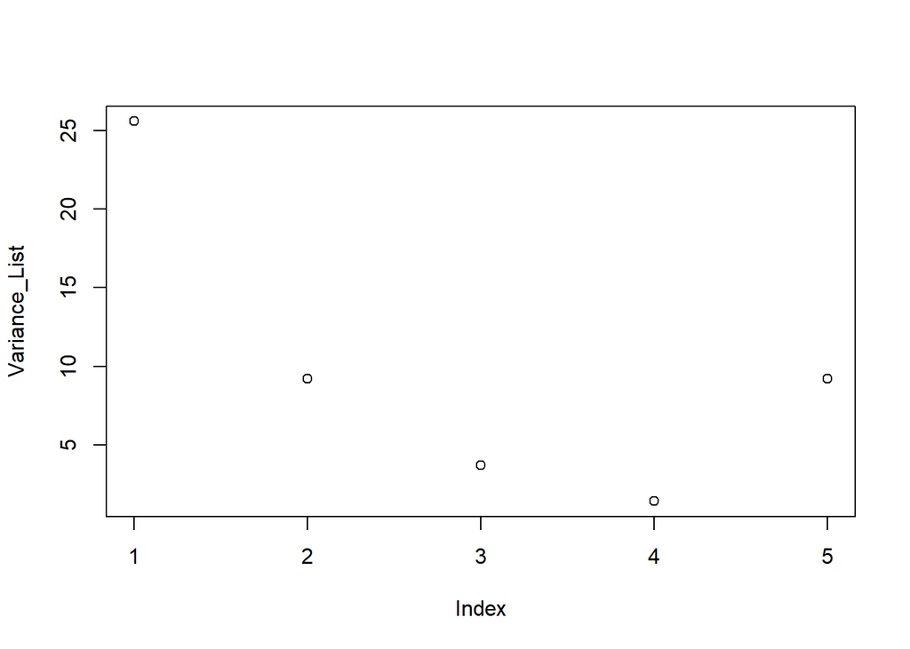

```r
plot(Variance_List)
```

Cluster 1: This cluster includes wines categorized as “Average” and “Poor”.

Cluster 2: Wines labeled as “Bad” belong to this cluster.

Cluster 3: This cluster consists of wines categorized as “Good”.

Cluster 4: Wines labeled as “Excellent” and “Very Good” are grouped into this cluster.

```r
#
# Saving four k-means clusters in a list
clus1 <- matrix(names(kmeans4.employ$cluster[kmeans4.employ$cluster == 1]),
                ncol=1, nrow=length(kmeans4.employ$cluster[kmeans4.employ$cluster == 1]))
colnames(clus1) <- "Cluster 1"
clus2 <- matrix(names(kmeans4.employ$cluster[kmeans4.employ$cluster == 2]),
                ncol=1, nrow=length(kmeans4.employ$cluster[kmeans4.employ$cluster == 2]))
colnames(clus2) <- "Cluster 2"
clus3 <- matrix(names(kmeans4.employ$cluster[kmeans4.employ$cluster == 3]),
                ncol=1, nrow=length(kmeans4.employ$cluster[kmeans4.employ$cluster == 3]))
colnames(clus3) <- "Cluster 3"
clus4 <- matrix(names(kmeans4.employ$cluster[kmeans4.employ$cluster == 4]),
                ncol=1, nrow=length(kmeans4.employ$cluster[kmeans4.employ$cluster == 4]))
colnames(clus4) <- "Cluster 4"
list(clus1,clus2,clus3,clus4)
```

```
## [[1]]
##      Cluster 1
## [1,] "Average"
## [2,] "Poor"
##
## [[2]]
##      Cluster 2
## [1,] "Good"
##
## [[3]]
##      Cluster 3
## [1,] "Bad"
##
## [[4]]
##      Cluster 4
## [1,] "Excellent"
## [2,] "Very Good"
```

Based on heatmap: Data matrix we can observe that Excellent and very good are strongly correlated and colored as blue

Bad, Poor, Average, Good have a similar behaviour based on clusters formed

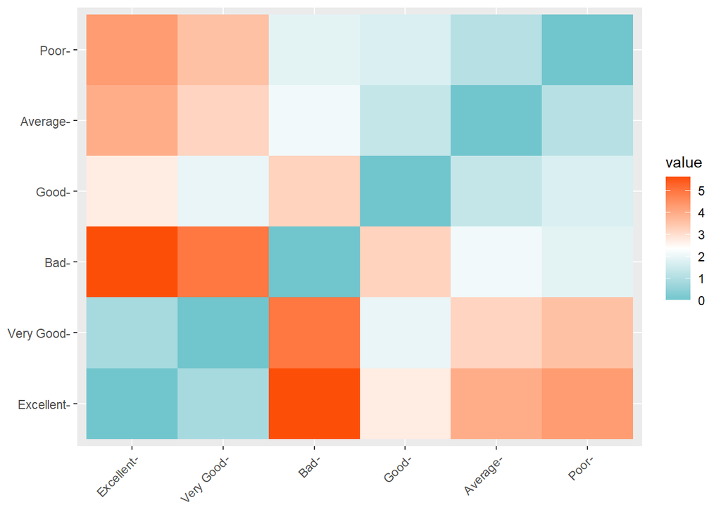

```r
# Assuming matstd.can is your data matrix

# Calculate the distance matrix
dist_matrix <- dist(matstd.can)

# Visualize the distance matrix
fviz_dist(dist_matrix, gradient = list(low = "#00AFBB", mid = "white", high = "#FC4E07"))
```

Observation:

Performing clustering using 2 clusters:

Very good and Excellent quality wine are in the same cluster

Bad, Poor, Average and good are in same cluster but highly seperated,

Bad seems to lie seperately

Poor and Average are very close

Good is also little close to Poor and Average

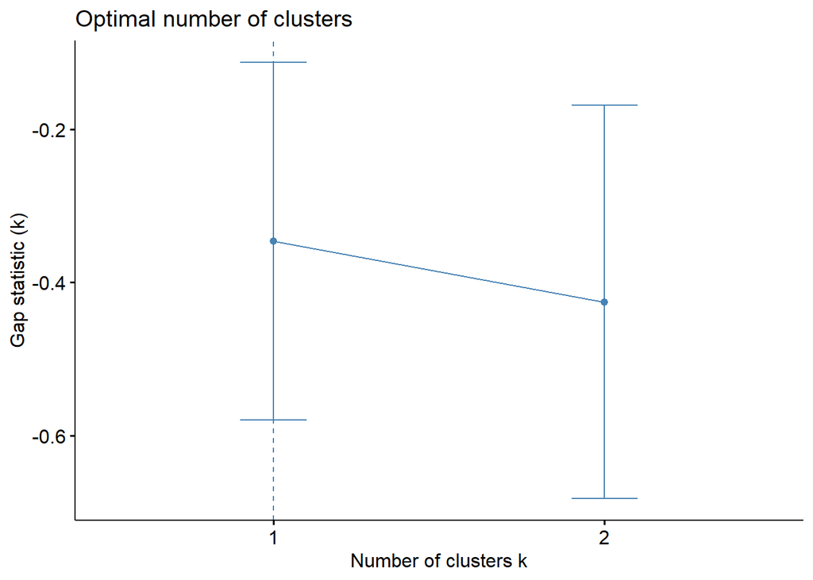

```r
# Load required libraries
library(factoextra)

# Visualize the optimal number of clusters using the gap statistic
fviz_nbclust(matstd.can, kmeans, method = "gap_stat", k.max = 2)
```

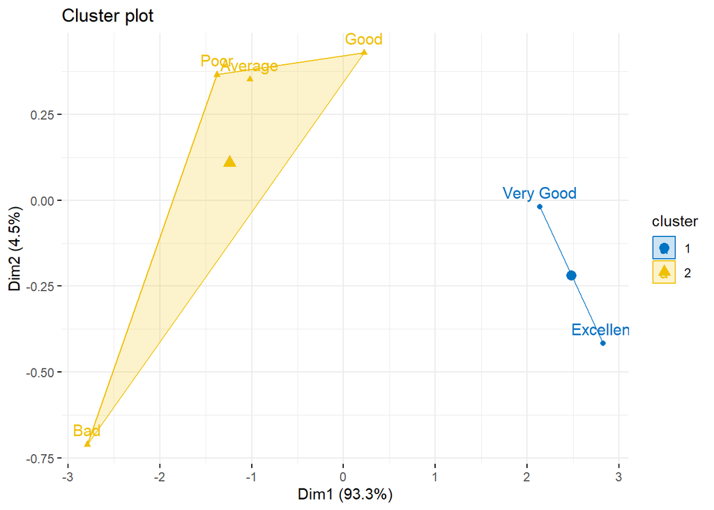

```r
set.seed(123)
km.res <- kmeans(matstd.can, 2, nstart = 25)
# Visualize
fviz_cluster(km.res, data = matstd.can,
             ellipse.type = "convex",
             palette = "jco",
             ggtheme = theme_minimal())
```

No. of cluster=3

This clustering provides more accurate clusters:

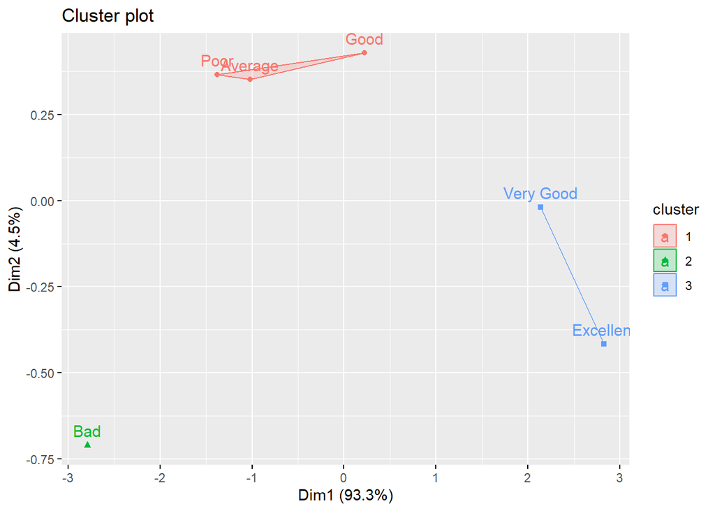

```r
# If your data has outliears , use PAM method
pam.res <- pam(matstd.can, 3)
# Visualize
fviz_cluster(pam.res)
```

```r
# Hierarchial Clusiering
res.hc <- matstd.can %>% scale() %>% dist(method = "euclidean") %>%
  hclust(method = "ward.D2")
```

This is perfect example of grouping based on hierarchial clusters:

Cluster group 1: Excellent and Very good share the same branch

Cluster 2: Poor, Average share the same branch

Cluster 3: Good quality wine is also seperated

Cluster 4: Bad quality wine is seperated

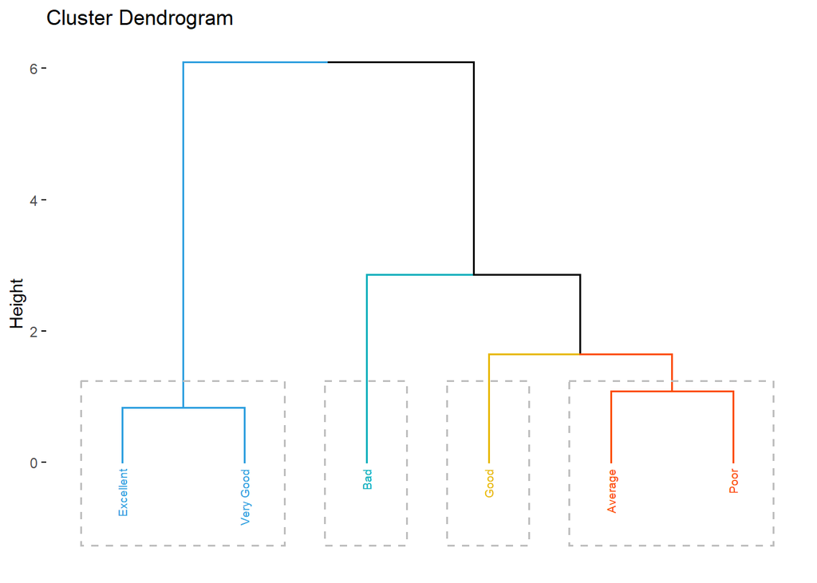

```r
fviz_dend(res.hc, k = 4, # Cut in four groups
          cex = 0.5, # label size
          k_colors = c("#2E9FDF", "#00AFBB", "#E7B800", "#FC4E07"),
          color_labels_by_k = TRUE, # color labels by groups
          rect = TRUE # Add rectangle around groups
          )
```

Viewing heigh based on cluster hierachy and have observation:

total height = -1 for excellent and very good

total height = -2 for bad, poor, average and good

Cluster 2 seems to have better-defined clusters with higher average silhouette width, indicating that the observations within Cluster 2 are more similar to each other and distinct from observations in other clusters.

Cluster 1, on the other hand, has a lower average silhouette width, suggesting that the observations within this cluster may not be as well-separated from observations in other clusters, potentially indicating less distinct clusters or overlap between clusters.

A higher average silhouette width generally indicates better clustering quality, as it implies that the clusters are more distinct and well-separated.

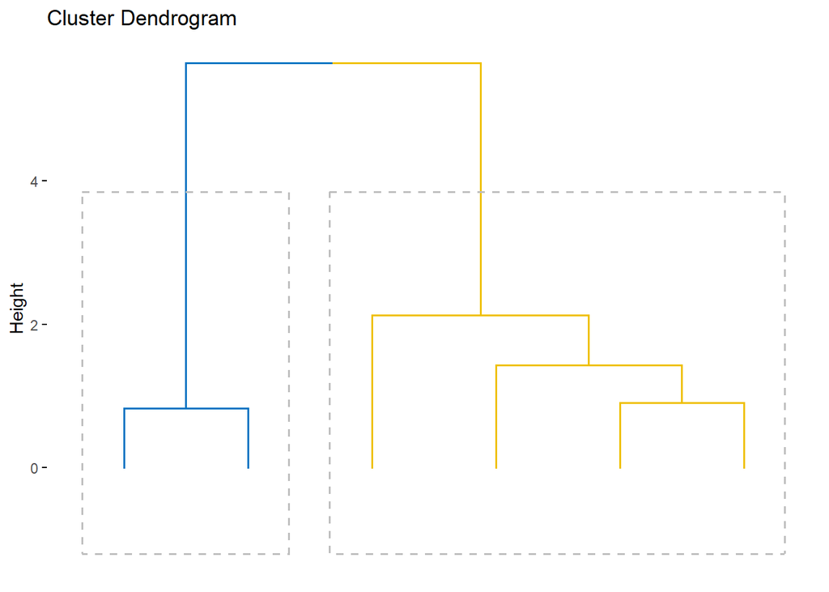

```r
# Quality of Clustering

set.seed(123)
# Enhanced hierarchical clustering, cut in 3 groups
res.hc <- matstd.can[, -1] %>% scale() %>%
  eclust("hclust", k = 2, graph = FALSE)

# Visualize with factoextra
fviz_dend(res.hc, palette = "jco",
          rect = TRUE, show_labels = FALSE)
```

[output not shown]

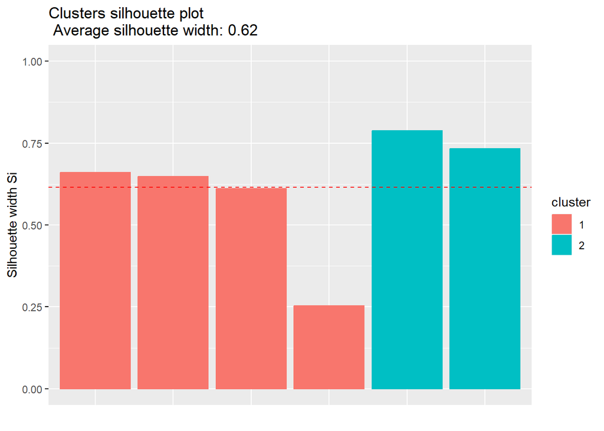

```r
#Inspect the silhouette plot:
fviz_silhouette(res.hc)
```

```r
# Silhouette width of observations
sil <- res.hc$silinfo$widths[, 1:3]

# Objects with negative silhouette
neg_sil_index <- which(sil[, 'sil_width'] < 0)
sil[neg_sil_index, , drop = FALSE]
```

```
## [1] cluster   neighbor  sil_width
## <0 rows> (or 0-length row.names)
```